# Tidyquant套件介紹

指導教授: 中山大學財務管理學系 王昭文 教授

文章撰寫: 中山大學財務管理學系 蘇彥庭 研究助理

2018年6月7日

## 前言

R語言在財務領域中，常用到的套件大概有下列幾個：

- [xts](https://cran.r-project.org/web/packages/xts/xts.pdf)/[zoo](https://cran.r-project.org/web/packages/zoo/zoo.pdf): 處理時間序列之套件。
- [TTR](https://cran.r-project.org/web/packages/TTR/TTR.pdf): 計算金融資產技術指標之套件。
- [quantmod](https://cran.r-project.org/web/packages/quantmod/quantmod.pdf): 金融資產技術分析回測套件，可至[Yahoo Finance](https://finance.yahoo.com/)或[Google Finance](https://finance.google.com/)下載歷史股價數據或其他金融相關數據。並且整合`TTR`套件，繪製出漂亮的技術分析圖析。
- [PerformanceAnalytics](https://cran.r-project.org/web/packages/PerformanceAnalytics/PerformanceAnalytics.pdf): 計算金融資產報酬績效指標之套件。

現在的R語言在資料科學的浪潮之下，資料數據格式已走向[tidy data](https://cran.r-project.org/web/packages/tidyr/vignettes/tidy-data.html)形式。[tidyverse](https://www.tidyverse.org/)套件已是每位R使用者必學的套件，使用此套件讓資料整理的程式碼簡潔又快速，讓R語言的方便性邁向更高一層。然而在財務領域的套件，目前皆是以時間序列資料格式(xts)為基礎建構而成。意即要使用這些套件的函數時，需要先將資料先轉為xts格式，才能做財務分析。若要在`tidyverse`套件中使用這些財務領域套件的函數，會有許多限制，需要做額外的整理才能使用，非常不方便。

針對這個痛點，R語言有人站出來解決這個問題，Matt Dancho和Davis Vaughan開發出[tidyquant](https://cran.r-project.org/web/packages/tidyquant/tidyquant.pdf)套件，為財務領域套件與`tidyverse`套件搭起一座橋梁，讓`tidyverse`套件能夠很輕易地使用財務領域套件。

[figure not shown]

圖1 tidyquant套件示意圖

(圖片截至於tidyquant套件的[影片介紹](https://www.youtube.com/embed/woxJZTL2hok))

`tidyquant`套件的作者Matt Dancho寫出許多詳盡的說明範例檔案，可參考以下連結:

- [Introduction to tidyquant](https://cran.r-project.org/web/packages/tidyquant/vignettes/TQ00-introduction-to-tidyquant.html)
- [Core Functions in tidyquant](https://cran.r-project.org/web/packages/tidyquant/vignettes/TQ01-core-functions-in-tidyquant.html#get-quantitative-data)
- [R Quantitative Analysis Package Integrations in tidyquant](https://cran.r-project.org/web/packages/tidyquant/vignettes/TQ02-quant-integrations-in-tidyquant.html)
- [Scaling and Modeling with tidyquant](https://cran.r-project.org/web/packages/tidyquant/vignettes/TQ03-scaling-and-modeling-with-tidyquant.html)
- [Charting with tidyquant](https://cran.r-project.org/web/packages/tidyquant/vignettes/TQ04-charting-with-tidyquant.html)
- [Performance Analysis with tidyquant](https://cran.r-project.org/web/packages/tidyquant/vignettes/TQ05-performance-analysis-with-tidyquant.html)

當然，本篇文章的說明也都是從以上的說明範例檔案來學習並寫出來的！差別在於我們是用中文說明及臺灣的股市價格資料來做範例，並只擷取重要部分，讓大家可以快速地掌握脈絡。

## 數據下載

做股市分析的第一步就是要取得股價資料，`tidyquant`套件的`tq_get()`函數整合`quantmod`套件的`getSymbols()`函數。透過`tq_get()`函數可以從網路上一次下載多檔股票資料，並且以`tibble`格式儲存資料，讓後續的資料處理更加方便。此處示範如何下載2017/06/01至2018/05/31，鴻海、台積電、中華電信及臺灣加權指數的歷史價格資料。在`tq_get()`函數內的引數為:

1. x: 金融資產的代碼，需配合資料源。
2. get: 資料下載來源，此處我們設定參數為`stock.price`，從[Yahoo Finance](https://finance.yahoo.com/)下載歷史股價資料。
3. from: 資料下載起始日。
4. to: 資料下載結束日。

`tq_get()`函數可下載的資料來源相當多，除了股價資料外，也有財務比率指標([Morningstar](https://www.morningstar.com/))、股利股息資料([Yahoo Finance](https://finance.yahoo.com/))及總經資料([FRED](https://fred.stlouisfed.org/))等，只要修改函數內的`get`參數即可取得。詳細內容可參考原作者的說明文件：[Core Functions in tidyquant](https://cran.r-project.org/web/packages/tidyquant/vignettes/TQ01-core-functions-in-tidyquant.html#get-quantitative-data)。

我們在[Yahoo Finance](https://finance.yahoo.com/)要下載的股票代碼為：鴻海(2317.TW)、台積電(2330.TW)及中華電信(2412.TW)及臺灣加權指數(^TWII)，程式碼寫法如下:

```r
# 載入套件
library(tidyquant)

# 下載資料
stockData <- c("^TWII", "2317.TW", "2330.TW", "2412.TW") %>%
  tq_get(get = "stock.price", from = "2017-06-01", to = "2018-05-31")

# 觀看資料
stockData
```

```
## # A tibble: 988 x 8
##    symbol       date     open     high      low    close  volume adjusted
##     <chr>     <date>    <dbl>    <dbl>    <dbl>    <dbl>   <dbl>    <dbl>
##  1  ^TWII 2017-06-01 10064.44 10100.37 10059.93 10087.42 1923600 10087.42
##  2  ^TWII 2017-06-02 10117.76 10152.53 10117.06 10152.53 2037600 10152.53
##  3  ^TWII 2017-06-03       NA       NA       NA       NA      NA       NA
##  4  ^TWII 2017-06-05 10164.89 10226.84 10164.89 10226.84 2141900 10226.84
##  5  ^TWII 2017-06-06 10213.17 10221.64 10190.39 10206.18 2016200 10206.18
##  6  ^TWII 2017-06-07 10216.14 10242.39 10183.15 10209.99 2172700 10209.99
##  7  ^TWII 2017-06-08 10215.93 10235.70 10211.00 10225.78 1703500 10225.78
##  8  ^TWII 2017-06-09 10238.55 10268.37 10198.80 10199.65 2139100 10199.65
##  9  ^TWII 2017-06-12 10137.04 10158.64 10109.96 10109.96 1746300 10109.96
## 10  ^TWII 2017-06-13 10109.70 10146.67 10109.70 10128.15 1586300 10128.15
## # ... with 978 more rows
```

簡單的兩行程式碼就可以下載多檔股票歷史數據，並整理成tibble資料格式，與`quantmod`套件的`getSymbols()`函數相比真的是方便很多。然而有一個問題是，[Yahoo Finance](https://finance.yahoo.com/)在台灣股市的資料維護其實並不太好。從上面下載的股價資料中，可以發現2017-06-03是以缺值資料紀錄，當日台股為端午節連假周六補交易日，[Yahoo Finance](https://finance.yahoo.com/)的資料庫卻沒有記錄到，這明顯是有問題的。所以我們在做台灣股市的量化資料分析時，並不會直接從網路上下載資料，會直接從財務資料庫來取得資料，確保資料品質。下一小節將說明如何讀入外部資料，並整理成`tidyquant`套件能使用的格式。

## 範例資料來源

除了透過`tq_get()`函數自[Yahoo Finance](https://finance.yahoo.com/)下載資料外，也可以從外部資料庫讀入數據，整理成`tidyquant`所需要的資料格式。此處以臺灣大專院校財金系最常使用的台灣經濟新報資料庫(TEJ)為例，透過特殊轉檔功能自TEJ下載資料輸出成txt檔案，然後再用R軟體讀入數據。資料期間為2017/06/01至2018/05/31之日頻調整後股價資料。分析資產標的分別為鴻海、台積電、中華電信股票及臺灣加權指數。

```r
# 讀取數據
stockData <- read.table("tej_data.txt", header = T, sep = "\t", stringsAsFactors = F) %>%
  as_data_frame()

# 整理資料欄位(依序為股票代碼、名稱、日期、開盤價、最高價、最低價、收盤價、成交量及成交金額)
colnames(stockData) <- c("code", "name", "date", "open", "high", "low", "close", "volume", "tradeValue")

# 將股票代碼及名稱空白格刪除
stockData <- stockData %>%
  mutate(code = gsub("\\s+","", code),
         name = gsub("\\s+","", name))

# 觀看資料
stockData
```

```
## # A tibble: 996 x 9
##     code     name     date     open     high      low    close  volume
##    <chr>    <chr>    <int>    <dbl>    <dbl>    <dbl>    <dbl>   <int>
##  1  2317     鴻海 20170601    99.57   100.53    99.09   100.53   27441
##  2  2330   台積電 20170601   198.39   200.32   197.90   200.32   29623
##  3  2412   中華電 20170601   103.13   103.60   102.65   103.13   10351
##  4 Y9999 加權指數 20170601 10064.44 10100.37 10059.93 10087.42 3935374
##  5  2317     鴻海 20170602   101.01   101.49   100.53   101.49   38194
##  6  2330   台積電 20170602   201.77   202.26   200.81   202.26   23265
##  7  2412   中華電 20170602   103.13   103.60   102.17   103.13    7341
##  8 Y9999 加權指數 20170602 10117.76 10152.53 10117.06 10152.53 4262071
##  9  2317     鴻海 20170603   101.01   101.49   100.53   101.01    9968
## 10  2330   台積電 20170603   202.26   202.26   201.29   202.26    1535
## # ... with 986 more rows, and 1 more variables: tradeValue <int>
```

由於TEJ資料庫我們採用特殊轉檔功能輸出，因此日期是以8碼數字格式儲存。為了讓`tidyquant`套件能夠運作，需將日期欄位由數字格式轉為日期格式。

```r
# 將8碼數字日期格式轉為日期格式
DateConvert <- function(date){
  date <- as.Date(as.character(date), "%Y%m%d")
  return(date)
}

stockData <- stockData %>% mutate(date = DateConvert(date))

# 觀看資料
stockData
```

```
## # A tibble: 996 x 9
##     code     name       date     open     high      low    close  volume
##    <chr>    <chr>     <date>    <dbl>    <dbl>    <dbl>    <dbl>   <int>
##  1  2317     鴻海 2017-06-01    99.57   100.53    99.09   100.53   27441
##  2  2330   台積電 2017-06-01   198.39   200.32   197.90   200.32   29623
##  3  2412   中華電 2017-06-01   103.13   103.60   102.65   103.13   10351
##  4 Y9999 加權指數 2017-06-01 10064.44 10100.37 10059.93 10087.42 3935374
##  5  2317     鴻海 2017-06-02   101.01   101.49   100.53   101.49   38194
##  6  2330   台積電 2017-06-02   201.77   202.26   200.81   202.26   23265
##  7  2412   中華電 2017-06-02   103.13   103.60   102.17   103.13    7341
##  8 Y9999 加權指數 2017-06-02 10117.76 10152.53 10117.06 10152.53 4262071
##  9  2317     鴻海 2017-06-03   101.01   101.49   100.53   101.01    9968
## 10  2330   台積電 2017-06-03   202.26   202.26   201.29   202.26    1535
## # ... with 986 more rows, and 1 more variables: tradeValue <int>
```

接下來我們將以此範例資料，來介紹`tidyquant`套件的函數用法。

## 計算技術指標寫法示範

此小節示範如何撰寫技術指標，主要是利用`tq_mutate()`函數，其引數依序為:

1. data: 資料集。
2. select: 選擇計算技術指標函數會使用到的資料欄位。
3. mutate_fun: 選擇要用的技術指標函數(`TTR`套件)。
4. 技術指標函數之參數設定。

透過`group_by()`函數搭配`tq_mutate()`函數以及`TTR`套件的技術指標函數，即可用簡潔的程式碼快速地計算出各支股票的技術指標值。以下為計算5日簡單移動平均線範例：

```r
# 計算簡單移動平均線參數
stockData <- stockData %>%
  arrange(code, date) %>%         # 資料排序
  group_by(code) %>%              # 以股票代碼為群組目標
  tq_mutate(select = c(close),    # 選擇收盤價
            mutate_fun = SMA,     # 選擇簡單移動平均線
            n = 5) %>%            # 5日簡單移動平均線參數
  rename(ma5 = SMA)               # 重新命名欄位

# 觀看資料
stockData %>%
  select(code, date, close, ma5) %>%
  arrange(code, date) %>%
  na.omit()
```

```
## # A tibble: 980 x 4
## # Groups:   code [4]
##     code       date  close     ma5
##    <chr>     <date>  <dbl>   <dbl>
##  1  2317 2017-06-06 101.01 101.106
##  2  2317 2017-06-07 101.01 101.202
##  3  2317 2017-06-08 101.01 101.106
##  4  2317 2017-06-09 101.01 101.106
##  5  2317 2017-06-12  98.13 100.434
##  6  2317 2017-06-13  98.13  99.858
##  7  2317 2017-06-14  98.13  99.282
##  8  2317 2017-06-15  98.61  98.802
##  9  2317 2017-06-16 101.01  98.802
## 10  2317 2017-06-19 105.34 100.244
## # ... with 970 more rows
```

如果要再算10日及20日簡單移動平均線，則繼續向後新增`tq_mutate()`:

```r
stockData <- stockData %>%

  # 計算10日簡單移動平均線參數
  tq_mutate(select = c(close),
            mutate_fun = SMA,
            n = 10) %>%
  rename(ma10 = SMA) %>%

  # 計算20日簡單移動平均線參數
  tq_mutate(select = c(close),
            mutate_fun = SMA,
            n = 20) %>%
  rename(ma20 = SMA)

# 觀看資料
stockData %>%
  select(code, date, close, ma10:ma20) %>%
  arrange(code, date) %>%
  na.omit()
```

```
## # A tibble: 920 x 5
## # Groups:   code [4]
##     code       date  close    ma10     ma20
##    <chr>     <date>  <dbl>   <dbl>    <dbl>
##  1  2317 2017-06-27 116.89 107.074 103.7780
##  2  2317 2017-06-28 113.52 108.613 104.4275
##  3  2317 2017-06-29 114.48 110.200 105.0770
##  4  2317 2017-06-30 112.56 111.355 105.6545
##  5  2317 2017-07-03 112.08 112.029 106.1840
##  6  2317 2017-07-04 108.71 111.885 106.5690
##  7  2317 2017-07-05 111.59 112.173 107.0980
##  8  2317 2017-07-06 111.11 112.461 107.6030
##  9  2317 2017-07-07 110.15 112.653 108.0600
## 10  2317 2017-07-10 111.11 112.220 108.7090
## # ... with 910 more rows
```

若要計算隨機指標，寫法為:

```r
stockData <- stockData %>%

  # 計算隨機指標
  tq_mutate(select = c(high, low, close),
            mutate_fun = stoch,
            nFastK = 14,
            nFastD = 3,
            nSlowD = 3)

# 觀看資料
stockData %>%
  select(code, date, fastK:stoch) %>%
  arrange(code, date) %>%
  na.omit()
```

```
## # A tibble: 928 x 5
## # Groups:   code [4]
##     code       date     fastK     fastD     stoch
##    <chr>     <date>     <dbl>     <dbl>     <dbl>
##  1  2317 2017-06-23 0.8218263 0.8337045 0.8790184
##  2  2317 2017-06-26 0.9496104 0.8644210 0.8597810
##  3  2317 2017-06-27 0.9536008 0.9083458 0.8688238
##  4  2317 2017-06-28 0.7907202 0.8979771 0.8902480
##  5  2317 2017-06-29 0.8371194 0.8604801 0.8889343
##  6  2317 2017-06-30 0.7443209 0.7907202 0.8497258
##  7  2317 2017-07-03 0.7211213 0.7675205 0.8062403
##  8  2317 2017-07-04 0.5365112 0.6673178 0.7418528
##  9  2317 2017-07-05 0.6746362 0.6440895 0.6929760
## 10  2317 2017-07-06 0.5755668 0.5955714 0.6356596
## # ... with 918 more rows
```

`tq_mutate()`函數內的`nFastK`、`nFastD`及`nSlowD`引數即為原`TTR`套件`stoch()`的引數。從上面的資料表可以發現，透過`tq_mutate()`函數，可將`TTR`套件`stoch()`函數跑出的3個欄位結果(`fastK`、`fastD`及`stoch`)全部新增在`stockData`資料表內。若沒有`tq_mutate()`這個函數，用`mutate()`函數計算隨機指標會是件很麻煩的事情。

若要計算MACD指標，寫法為:

```r
stockData <- stockData %>%

  # 計算MACD指標
  tq_mutate(select = close,
            mutate_fun = MACD,
            nFast = 12,
            nSlow = 26,
            nSig  = 9)

# 觀看資料
stockData %>%
  select(code, date, macd:signal) %>%
  arrange(code, date) %>%
  na.omit()
```

```
## # A tibble: 864 x 4
## # Groups:   code [4]
##     code       date     macd   signal
##    <chr>     <date>    <dbl>    <dbl>
##  1  2317 2017-07-17 3.399607 3.703507
##  2  2317 2017-07-18 3.414634 3.645732
##  3  2317 2017-07-19 3.385078 3.593601
##  4  2317 2017-07-20 3.286600 3.532201
##  5  2317 2017-07-21 3.066426 3.439046
##  6  2317 2017-07-24 2.928384 3.336914
##  7  2317 2017-07-25 2.855695 3.240670
##  8  2317 2017-07-26 2.661369 3.124810
##  9  2317 2017-07-27 2.617056 3.023259
## 10  2317 2017-07-28 2.551553 2.928918
## # ... with 854 more rows
```

和隨機指標寫法架構一樣，`tq_mutate()`函數內的`nFast`、`nSlow`及`nSig`引數即為原`TTR`套件`MACD()`的引數。

## 計算績效指標寫法示範

有時我們會想要計算每個股票的績效指標，進行一些財務分析(例如建構投資組合及股票評價等)。`tidyquant`套件完美地整合`PerformanceAnalytics`套件，讓我們很方便地去計算績效指標。在計算績效指標時，我們需先將各檔股票股價資料整理成報酬率資料，並額外整理出臺灣加權指數報酬率做為市場報酬率，資料整理範例如下：

```r
# 計算各資產報酬率
stockRet <- stockData %>%
  select(code:date, close) %>%
  group_by(code) %>%
  arrange(code, date) %>%
  mutate(ret = close/lag(close)-1) %>%
  ungroup() %>%
  na.omit()

# 整理市場報酬率
mktRet <- stockRet %>%
  filter(code == "Y9999") %>%
  select(date, ret) %>%
  rename(mktRet = ret)

# 整理各資產報酬率並且併入各交易日對應的市場報酬率
stockRet <- stockRet %>%
  select(code:date, ret) %>%
  filter(code != "Y9999") %>%
  left_join(mktRet, by = c("date" = "date"))
```

整理完後的資料，每個資產在每個交易日都有日報酬率和當日對應的市場報酬率，如下所示：

```r
stockRet
```

```
## # A tibble: 744 x 5
##     code  name       date          ret        mktRet
##    <chr> <chr>     <date>        <dbl>         <dbl>
##  1  2317  鴻海 2017-06-02  0.009549388  0.0064545741
##  2  2317  鴻海 2017-06-03 -0.004729530  0.0005535566
##  3  2317  鴻海 2017-06-05  0.004752005  0.0067620581
##  4  2317  鴻海 2017-06-06 -0.004729530 -0.0020201744
##  5  2317  鴻海 2017-06-07  0.000000000  0.0003733032
##  6  2317  鴻海 2017-06-08  0.000000000  0.0015465245
##  7  2317  鴻海 2017-06-09  0.000000000 -0.0025553063
##  8  2317  鴻海 2017-06-12 -0.028512029 -0.0087934390
##  9  2317  鴻海 2017-06-13  0.000000000  0.0017992158
## 10  2317  鴻海 2017-06-14  0.000000000 -0.0054985363
## # ... with 734 more rows
```

接下來示範如何計算績效指標，主要是透過`tq_performance()`函數，其引數依序為:

1. data: 資料集。
2. Ra: 資產報酬率。
3. Rb: 市場基準報酬率。
4. performance_fun: 績效指標函數(`PerformanceAnalytics`套件)。
5. 績效指標函數之參數設定。

以計算常用的夏普比率為例，此處假設無風險年利率為1%，程式寫法如下。需注意的地方是，計算夏普比率時不需要用到市場報酬率，因此Rb的參數我們給NULL值。

```r
sharpeRatio <- stockRet %>%
  group_by(code) %>%
  tq_performance(Ra = ret,
                 Rb = NULL,
                 performance_fun = SharpeRatio,
                 Rf = 0.01/252)

# 觀看資料
sharpeRatio
```

```
## # A tibble: 3 x 4
## # Groups:   code [3]
##    code `ESSharpe(Rf=0%,p=95%)` `StdDevSharpe(Rf=0%,p=95%)`
##   <chr>                   <dbl>                       <dbl>
## 1  2317             -0.02012416                 -0.03741787
## 2  2330              0.01323757                  0.03772705
## 3  2412              0.01668980                  0.03367462
## # ... with 1 more variables: `VaRSharpe(Rf=0%,p=95%)` <dbl>
```

和`tq_mutate()`函數架構一樣，`tq_performance()`函數內的`Rf`引數為原`PerformanceAnalytics`套件`SharpeRatio()`的引數。

若要跑資本資產定價模型(CAPM)，則寫法為:

```r
capmTable <- stockRet %>%
  group_by(code) %>%
  tq_performance(Ra = ret,
                 Rb = mktRet,
                 performance_fun = table.CAPM,
                 Rf = 0.01/252)

# 觀看資料
capmTable
```

```
## # A tibble: 3 x 13
## # Groups:   code [3]
##    code ActivePremium  Alpha AnnualizedAlpha   Beta `Beta-` `Beta+`
##   <chr>         <dbl>  <dbl>           <dbl>  <dbl>   <dbl>   <dbl>
## 1  2317       -0.2291 -1e-03         -0.2167 1.3815  1.1093  1.5340
## 2  2330        0.0408  1e-04          0.0161 1.5010  1.3020  1.6403
## 3  2412       -0.0215  1e-04          0.0248 0.3600  0.3675  0.4613
## # ... with 6 more variables: Correlation <dbl>,
## #   `Correlationp-value` <dbl>, InformationRatio <dbl>, `R-squared` <dbl>,
## #   TrackingError <dbl>, TreynorRatio <dbl>
```

## 資料頻率轉換

上述計算績效指標時皆採用日頻資料，但一般常見的作法是用月頻資料來計算績效指標。在`tidyquant`套件中，使用`tq_transmute()`函數搭配原本`quantmod`套件內的`periodReturn()`函數，可以很輕易地對資料做頻率轉換。`tq_transmute()`的引數依序為:

1. data: 資料集。
2. select: 選擇資料欄位。
3. mutate_fun: 套件函數。
4. col_rename: 新增的欄位名稱。
5. 套件函數之參數設定。

```r
# 轉換成月頻資料
stockMonthRet <- stockData %>%
  group_by(code) %>%
  tq_transmute(select = close,
               mutate_fun = periodReturn,
               col_rename = "monthRet",
               period = "monthly")

# 觀看資料
stockMonthRet
```

```
## # A tibble: 48 x 3
## # Groups:   code [4]
##     code       date     monthRet
##    <chr>     <date>        <dbl>
##  1  2317 2017-06-30  0.119665771
##  2  2317 2017-07-31  0.043887704
##  3  2317 2017-08-31  0.000000000
##  4  2317 2017-09-30 -0.089361702
##  5  2317 2017-10-31  0.046728972
##  6  2317 2017-11-30 -0.107142857
##  7  2317 2017-12-29 -0.048000000
##  8  2317 2018-01-31 -0.031512605
##  9  2317 2018-02-27 -0.044468547
## 10  2317 2018-03-31  0.004540295
## # ... with 38 more rows
```

如果想要計算季頻或年頻，只要在`period`參數改成`quarterly`或`yearly`即可：

```r
# 轉換成季頻資料
stockQuarterRet <- stockData %>%
  group_by(code) %>%
  tq_transmute(select = close,
               mutate_fun = periodReturn,
               col_rename = "monthRet",
               period = "quarterly")

# 觀看資料
stockQuarterRet
```

```
## # A tibble: 20 x 3
## # Groups:   code [4]
##     code       date     monthRet
##    <chr>     <date>        <dbl>
##  1  2317 2017-06-30  0.119665771
##  2  2317 2017-09-30 -0.049395878
##  3  2317 2017-12-29 -0.110280374
##  4  2317 2018-03-31 -0.070378151
##  5  2317 2018-05-31 -0.031638418
##  6  2330 2017-06-30  0.040834665
##  7  2330 2017-09-30  0.038369305
##  8  2330 2017-12-29  0.060046189
##  9  2330 2018-03-31  0.078431373
## 10  2330 2018-05-31 -0.094949495
## 11  2412 2017-06-30  0.000000000
## 12  2412 2017-09-30  0.013284204
## 13  2412 2017-12-29  0.014354067
## 14  2412 2018-03-31  0.066037736
## 15  2412 2018-05-31 -0.035398230
## 16 Y9999 2017-06-30  0.030498383
## 17 Y9999 2017-09-30 -0.001070700
## 18 Y9999 2017-12-29  0.024934659
## 19 Y9999 2018-03-31  0.025992074
## 20 Y9999 2018-05-31 -0.004078029
```

```r
# 轉換成年頻資料
stockYearRet <- stockData %>%
  group_by(code) %>%
  tq_transmute(select = close,
               mutate_fun = periodReturn,
               col_rename = "monthRet",
               period = "yearly")

# 觀看資料
stockYearRet
```

```
## # A tibble: 8 x 3
## # Groups:   code [4]
##    code       date    monthRet
##   <chr>     <date>       <dbl>
## 1  2317 2017-12-29 -0.05301900
## 2  2317 2018-05-31 -0.09978992
## 3  2330 2017-12-29  0.14566693
## 4  2330 2018-05-31 -0.02396514
## 5  2412 2017-12-29  0.02782895
## 6  2412 2018-05-31  0.02830189
## 7 Y9999 2017-12-29  0.05506264
## 8 Y9999 2018-05-31  0.02180805
```

## 繪製圖形

`tidyquant`除了將財務領域套件與`dplyr`套件做結合外，與`ggplot2`繪圖套件也整合得相當好，接下來將會展現幾個範例。

- 繪製股價日頻走勢圖

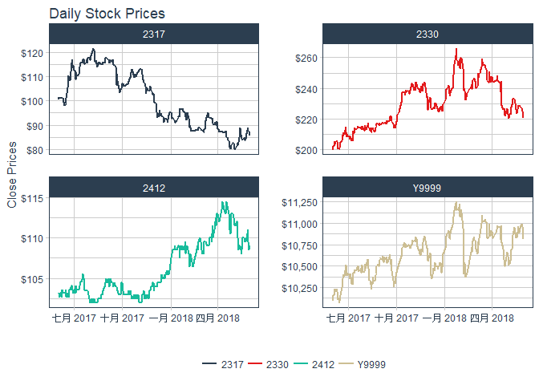

```r
stockData %>%
  ggplot(aes(x = date, y = close, color = code)) +
  geom_line(size = 1) +
    labs(title = "Daily Stock Prices",
         x = "", y = "Close Prices", color = "") +
    facet_wrap(~ code, ncol = 2, scales = "free_y") +
    scale_y_continuous(labels = scales::dollar) +
    theme_tq() +
    scale_color_tq()
```

- 繪製技術分析圖形(以台積電為例)

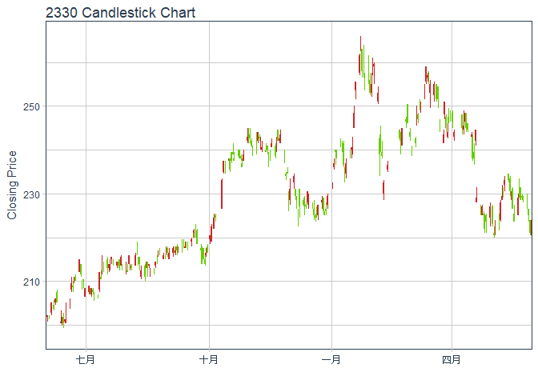

```r
stockData %>%
  filter(code == "2330") %>%
  ggplot(aes(x = date, y = close)) +
  geom_candlestick(aes(open = open, high = high, low = low, close = close),
                   color_up = "firebrick3", color_down = "chartreuse3",
                   fill_up  = "firebrick3", fill_down  = "chartreuse3") +
  labs(title = "2330 Candlestick Chart", y = "Closing Price", x = "") +
  theme_tq() +
  scale_x_date(expand = c(0, 0))
```

- 繪製技術分析圖形(以台積電為例)及5日、10日及20日均線

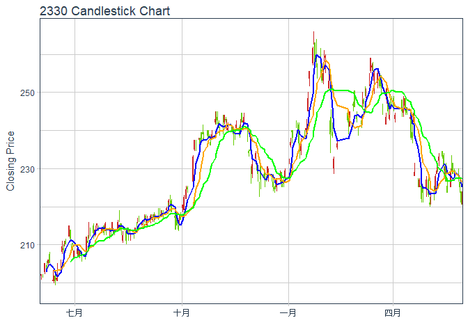

```r
stockData %>%
  filter(code == "2330") %>%
  ggplot(aes(x = date, y = close)) +
  geom_candlestick(aes(open = open, high = high, low = low, close = close),
                   color_up = "firebrick3", color_down = "chartreuse3",
                   fill_up  = "firebrick3", fill_down  = "chartreuse3") +
  geom_ma(ma_fun = SMA, n = 5, color = "blue", linetype = 7,size = 1) +
  geom_ma(ma_fun = SMA, n = 10, color = "orange", linetype = 7, size = 1) +
  geom_ma(ma_fun = SMA, n = 20, color = "green", linetype = 7, size = 1) +
  labs(title = "2330 Candlestick Chart", y = "Closing Price", x = "") +
  theme_tq() +
  scale_x_date(expand = c(0, 0))
```

- 繪製技術分析圖形(以台積電為例)及布林通道

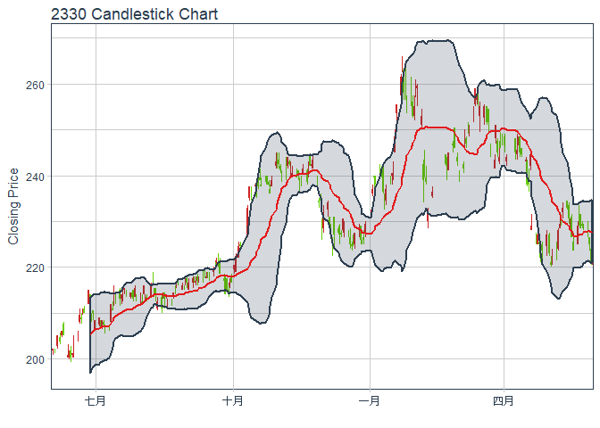

```r
stockData %>%
  filter(code == "2330") %>%
  ggplot(aes(x = date, y = close, open = open, high = high, low = low, close = close)) +
  geom_candlestick(color_up = "firebrick3", color_down = "chartreuse3",
                   fill_up  = "firebrick3", fill_down  = "chartreuse3") +
  geom_bbands(ma_fun = SMA, sd = 2, n = 20,
              linetype = 7, size = 1, alpha = 0.2,
              fill = palette_light()[[1]],
              color_bands = palette_light()[[1]],
              color_ma = palette_light()[[2]]) +
  labs(title = "2330 Candlestick Chart", y = "Closing Price", x = "") +
  theme_tq() +
  scale_x_date(expand = c(0, 0))
```

## 結語

從上述的範例中，可以看到`tidyquant`套件很棒地將財務套件與`tidyverse`套件完美地結合。不用再寫太多複雜的程式和迴圈，繞來繞去地去計算每支股票的技術指標和績效指標。這個套件的整合，對於用R語言做財務分析的使用者來說真是一大福音！本篇文章僅擷取`tidyquant`套件最重要的部分，但原作者撰寫的說明文章還有更多細節及應用，對於此套件有興趣的讀者，建議可去點閱來看。